# Respiratory Explainer

Jeffrey A. Walker

21 July, 2021

# Ventillation

## pressure-volume

Pressure and volume are inversely related in a gas filled container

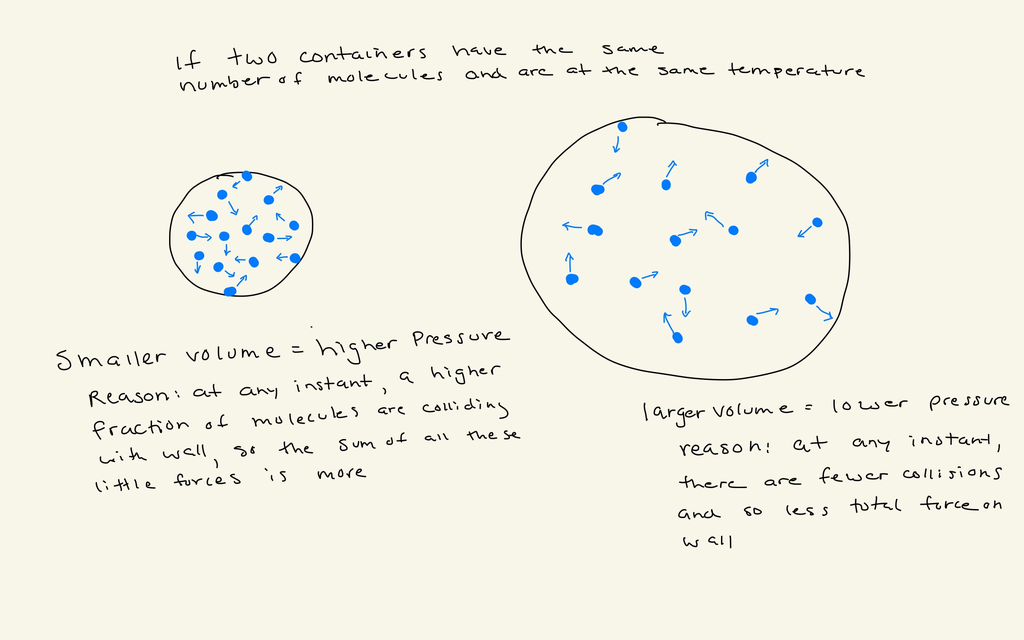

## ventillation

We ventillate the lungs with a “suction pump”. We inspire by expanding our thorax, which lowers the pressure inside the alveoli ($P_{alv}$) relative to the pressure outside our body ($P_{atm}$). This pressure gradient “sucks” air into the lungs. We expire by squeezing the lungs (this is not active muscle-driven compression but elastic rebound from the expanded elastic tissues of the lung and thorax), which increases $P_{alv}$ relative to $P_{atm}$. This pressure gradient “pushes” air out of the lungs.

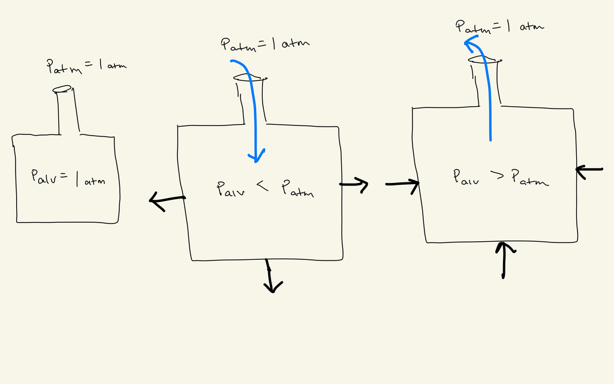

Think about it like this: Immediately before inspiration begins, $P_{alv} = P_{atm}$. The lungs start to expand and the pressure drops a little, so that $P_{alv} < P_{atm}$, and air flows in. The increased number of gas molecules in the alveoli increases alveolar pressure so that $P_{alv} = P_{atm}$. The lungs expand a little more and the pressure drops so that $P_{alv} < P_{atm}$, and air flows in. The increased number of gas molecules in the alveoli increases alveolar pressure so that $P_{alv} = P_{atm}$. The lungs expand a little more and the pressure drops so that $P_{alv} < P_{atm}$, and air flows in. The increased number of gas molecules in the alveoli increases alveolar pressure so that $P_{alv} = P_{atm}$. The actual process isn’t a series of steps like this. The lungs continuously expand and $P_{alv}$ stays slightly less than $P_{atm}$ throughout inspiration, but only slightly less because more air flows in.

# Transport of O2

## Pulmonary capillary

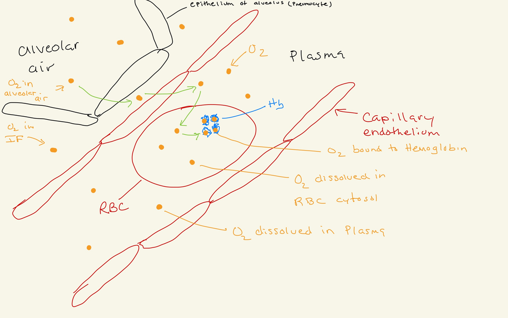

It’s important to keep in mind all the “compartments” with O2 during transport from lungs to systemic tissues and back to lungs. In the pulmonary capillaries, the compartments are 1) alveolar air, 2) alveolar cytosol, 3) interstitial fluid, 4) endothelial cytosol, 5) plasma, 6) RBC cytosol, 7) hemoglobin. There is *net* transport of O2 in this order, but individual O2 molecules are constantly moving back and forth between compartments – remember there is a *net* transport in this direction because this is the direction of the diffusion gradients. This gradient is ultimately created by the delivery of fresh air to the alvolus and the removal of O2 by binding to Hb. The alveolus is a source. The Hb is a sink.

99% of O2 is transported bount to hemoglobin but there is always a small fraction dissolved in the plasma and dissolved in the cytosol of RBCs (and WBCs of course, but there are very few of these)

## systemic capillary

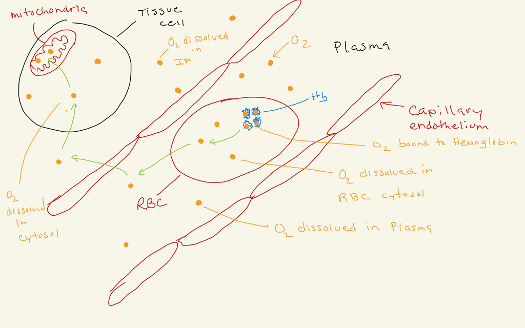

In the systemic capillaries, the compartments are 1) hemoglobin, 2) RBC cytosol, 3) plasma, 4) endothelial cytosol, 5) IF, 6) sytemic cell cytosol, 7) mitochondria. There is *net* transport of O2 in this order, but individual O2 molecules are constantly moving back and forth between compartments – remember there is a *net* transport in this direction because this is the direction of the diffusion gradients. This gradient is ultimately created by the delivery of O2 via the capillary and the consumption of O2 by the mitochondria. The capillary is a source. The mitochondria is a sink.

## Partial pressure of blood gases (O2 and CO2)

tl;dr: The partial pressure of a blood gas is a measure of the concentration of the dissolved gas in the blood – it is not a partial pressure as applied to gas in air, or any kind of pressure. The units of partial pressure of a dissolved gas is units of pressure (typically mmHg) – don’t let the units confuse you; the partial pressure of a dissolved gas is not a pressure. Don’t let the name confuse you – the “partial pressure” of blood O2 is not the fraction of the blood pressure due to O2 molecules colliding with the wall.

Think about the absurdity of this – Blood pressure in the veins is about 8 mmHg, the partial pressure of venous O2 is about 40 mmHg - how can the part (40 mmHg, the component due to O2) be more than the whole (8 mmHg)? It cannot!

The partial pressure of a blood gas is a measure of the concentration of the dissolved gas in the blood with a really terrible name but *useful* units.

The long version: Let’s back up. **Concentration** is – like density – a measure of the amount of something per area or per volume. Biologists and chemists typically use **molarity** to measure the concentration of solutes in a solution. For example, typical plasma Na+ is about 135 mmol/L (millimoles Na+ per liter of plasma). Remember that a mole of Na+ is 6.02 x $10^{23}$ Na+ ions. Sometimes other units are used, for example fasting blood glucose is often given in units of mg/dL (miligrams of glucose per deciliter of plasma).

The concentration of dissolved O2 in arterial blood is typically 100 mmHg. Why these weird units? The reason for using these units is that these units allow a respiratory physiologist to understand **external respiration**, the exchange of O2 and CO2 across the **respiratory membrane**.

To get this, we need to know what a **partial pressure** of a gas in air is. A real partial pressure, not the “partial pressure” of a dissolved gas. Air is a **gas mixture**, it is composed of many kinds of molecules, all in gas phase.

1. What is **gas phase**? Gas phase simply means that the molecules have too much kinetic energy to interact and form short term bonds (like hydrogen bonds) when they collide. They just bounce off each other. Because they don’t form these short term bonds, they tend to be, on average, far apart (relative to a liquid or a solid) - and we humans experience this as something like air (a gas)
2. What is **liquid phase**? In a liquid, the molecules have small enough kinetic energy that they interact when they collide and form short term bonds like hydrogen bonds. Water is cool because H2O molecules are so attracted to each other that H2O goes into liquid phase at pretty high kinetic energies, that is, water is liquid at pretty high temperatures (the temperatures that we experience). By comparison N2 doesn’t form a liquid until the temperature drops below -320 F!

So air is a gas mixture made up of different gases. The two major gases are N2, which makes up about 78% of air, and O2, which makes up about 21% of air. Other gases like methane and CO2 make up only a tiny fraction. These fractions ignore water vapor (they are of *dry* air), since the amount of H2O in air varies from about .2% to about 4%. The pressure of a gas is the force a gas exerts on a surface divided by the area of the surface. The force comes from the gas molecules colliding with the surface. Since O2 makes up 21% of the gas molecules in air, then 21% of the molecules colliding with the surface are O2 and 21% of the force is due to O2 collisions. Or 21% of the pressure is due to O2. This is called the **partial pressure** of O2. The partial pressure of a gas in a gas mixture is

$$\begin{equation}
P_{gas} = \frac{\%_{gas}}{100} \times P_{air}
\end{equation}$$

This is **Dalton’s law of partial pressure**. Air pressure at the earth’s surface is about 760 mmHg so the partial pressure of O2 in air at the earth’s surface is

$$\begin{align}
P_{O2} &= \frac{21}{100} \times 760 \; \mathrm{mmHg}\\
&=160 \; \mathrm{mmHg}
\end{align}$$

This only applies to gases in a gas mixture. It does not apply to gases dissolved in a liquid, such as O2 in the blood. The “partial pressure” of blood O2 is not the fraction of the blood pressure due to O2 molecules colliding with the wall.

Think about the absurdity of this – Blood pressure in the veins is about 8 mmHg, the partial pressure of venous O2 is about 40 mmHg - how can the part (40 mmHg, the component due to O2) be more than the whole (8 mmHg)? It cannot!

So what does partial pressure have to do with the concentration of O2 (or CO2) in plasma?

If we place a cup filled with plasma on the table, some O2 molecules will convert to a gas phase and “come out of solution”. These will evaporate from the plasma and become part of the air. Some O2 molecules in the air will “go into solution” – they leave the air and become a solute in the plasma. If the cup is filled with fresh plasma, the system is not at equilibrium and more O2 will go into solution than come out. Since more O2 is dissolving in the plasma then coming out of solution, the concentration of the dissolved O2 will increase. Will it increase forever? No, it will increase until the system is at equilibrium. At equilibrium the number of O2 molecules going from the air into solution equals the number of O2 molecules coming out of solution into the air.

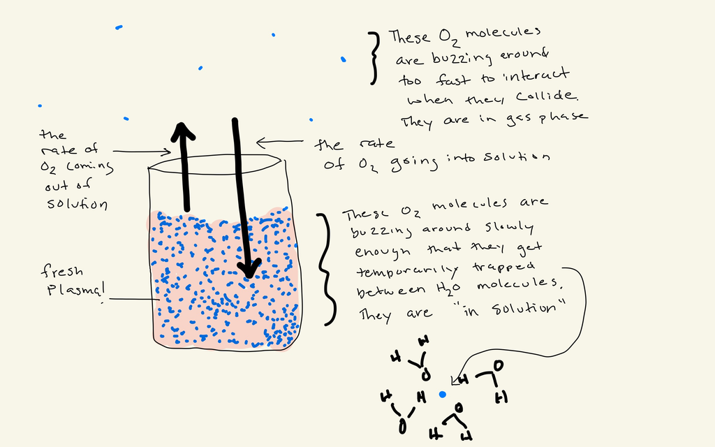

At equilibrium, we say that the concentration of O2 dissolved in the blood is the partial presure of O2 in the air – the two values are equal. So the PO2 in the plasma in the cup will be 160 mmHg. When you read that the concentration of dissolved O2 in the veins is 40 mmHg, this means that if we filled a cup with venous blood and placed it into a closed container of air, the dissolved O2 would be in equilibrium with the air O2 if the PO2 in the air were 40 mmHg. Again, this is a weird measure of concentration of dissolved O2 and not at all what is meant by “partial pressure” in Dalton’s law. “Partial pressure” is a terrible name for this.

Even though using mmHg as the units of dissolved O2 concentration in the plasma is weird, it is useful because this allows us to track what is happening when a system is out of equilibrium. In order to do this, we need to use the same measure of the concentration of O2 in the plasma and in the air and this measure is partial pressure. If the PO2 of the blood entering the pulmonary capillary is 40 mmHg and the PO2 in alveolar air is 104 mmHg the system is out of equilibrium and there will be net movement of O2 “into solution” – from the alveolar air into the capillary blood – raising the capillary PO2 until equilibrium, which is 104 mmHg.

#### Way too much information – understand Henry’s law for your own enjoyment

Finally, here is something really weird about partial pressure as a measure of concentration. The concentration of dissolved CO2 when the PCO2 is 40 mmHg and the concentration of dissolved O2 when the PO2 is 40 mmHg is not the same! Huh? As a measure of concentration, the partial pressure of a dissolved gas is specific to that gas! The reason for this is because the concentration of a gas dissolved in solvent at equilibrium is not just a function of the partial pressure of the gas in air but of the **solubility** of the gas in that solvent and this relationship is described by **Henry’s law**

$$\begin{equation}
[gas] = c_{gas}P_{gas}
\end{equation}$$

Here $c_{gas}$ is Henry’s solubility coefficient and the units are $\frac{\mathrm{mole}}{\mathrm{L}\;\mathrm{atm}}$ so the units of concentration of the dissolved gas is molarity ($\frac{\mathrm{mole}}{\mathrm{L}}$) - ah, how nice is that? Let’s plug in numbers. First, convert 40 mmHg to atm. 1 atm = 760 mmHg so

$$\begin{equation}
40\;\mathrm{mmHg}\;\frac{1\;\mathrm{atm}}{760\;\mathrm{mmHg}} = .053\;\mathrm{atm}
\end{equation}$$

And (pauses to look up in wikipedia) $c_{CO2}$ in water is about .034 $\frac{\mathrm{mole}}{\mathrm{L}\;\mathrm{atm}}$ and $c_{O2}$ is about .0013 $\frac{\mathrm{mole}}{\mathrm{L}\;\mathrm{atm}}$, so

$$\begin{align}
[CO2] &= 0.034\;\frac{\mathrm{mole}}{\mathrm{L}\;\mathrm{atm}} \; .053\;\mathrm{atm}\\
&=0.0018\;\frac{\mathrm{mole}}{\mathrm{L}}\\
&=1.8\;\mathrm{mmol}
\end{align}$$

$$\begin{align}
[O2] &= 0.0013\;\frac{\mathrm{mole}}{\mathrm{L}\;\mathrm{atm}} \; .053\;\mathrm{atm}\\
&=0.000069\;\frac{\mathrm{mole}}{\mathrm{L}}\\
&=0.069\;\mathrm{mmol}
\end{align}$$

or about 26 times more dissolved CO2 than dissolved O2 even though these have the same partial pressure (these partial pressures are about that in systemic venous blood or arterial blood going to the pulmonary capillary).

## The oxy-hemoglobin dissociation curve

Why do we care about PO2 since only a tiny fraction (about 1%) of O2 is transported as dissolved O2? One reason is because the PO2 determines how much O2 is bound to hemoglobin and, therefore, how much total O2 is transported in the blood. This is a really, really important concept clinically and not just for lab physiologists.

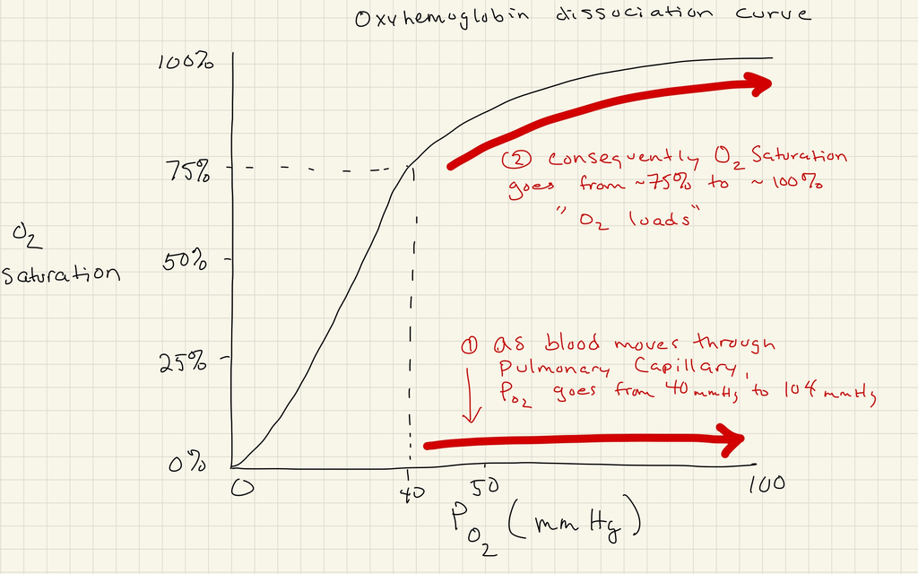

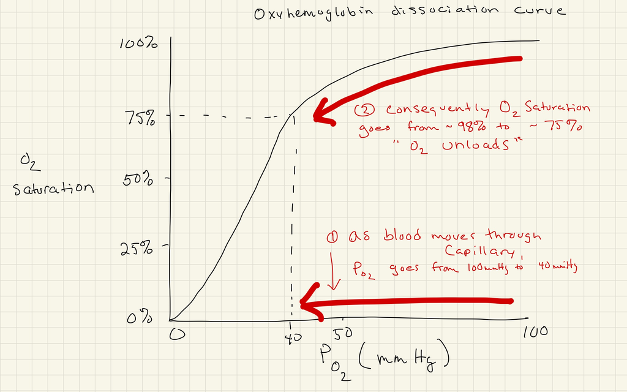